# Normes sociales en rapport à l’enrégistrement des naissances, marriages et décès au Burkina Faso

Ramoudane Orou Sannou

11/13/2019

# 1. Context

Au-delà d’être un simple moyen de communication, le système linguistique d’une communauté est aussi un vecteur de pensée collective. Cette position est d’autant plus renforcée lorsqu’il s’agit des opinions sur des questions sensibles directement liées à la morale et à la culture, comme les naissances, les mariages et les décès. Ainsi, la compréhension des questions délicates relatives à l’enregistrement des naissances, des mariages et des décès pourrait être réalisée grâce à une étude attentive de l’utilisation de la langue.

La présente étude fait partie d’un projet de recherche visant à étudier les connaissances, les normes sociales et les pratiques culturelles associées à l’enregistrement des naissances, des mariages et des décès au Burkina Faso. Pour un scientific des données, une question qui vient aussitôt à l’esprit est : Est-il possible d’utiliser l’analyse de text (text mining), le Natural Language Processing (NLP), l’apprentissage automatique et d’autres méthodes de la science des données pour mieux comprendre un tel sujet ?

Faisant office d’analyse exploratoire, ce R markdown tentera de faire la lumière sur certaines questions clés discutées dans les publications sur les naissances, les mariages et les décès au Burkina Faso. Il est conçu pour fournir à notre étude sur les déterminants immédiats du sous-enregistrement des événements vitaux au Burkina Faso, un flux d’informations pour mieux préparer les entretiens sur le terrain/ focus group et potentiellement, guider les analyses. Il vise également à plaider en faveur de nouvelles études sur les normes sociales qui déterminent l’enregistrement des faits d’état civil tout en encourageant l’utilisation de nouvelles méthodes de collecte de données dans ce genre d’étude.

# 2. Le Text mining: l’analyse de text

Le text mining est un processus d’analyse de texte qui vise à découvrir des informations pertinentes qui sont peut-être inconnues ou enfouies sous les mots. Il utilise de Natural Language Processing (traitement du langage naturel) en tentant de déchiffrer les ambiguïtés du langage écrit par tokenisation (transformation d’un text en une collection de mots), clustering (catégorisation des mots par apprentissage automatique), extraction de relations d’entités et de mots, et en utilisant des algorithmes pour identifier des thèmes et quantifier des informations subjectives [(Liske, 2018)](https://www.datacamp.com/community/tutorials/R-nlp-machine-learning). Pour cette étude, nous tenterons de déchiffrer à partir de notre analyse la pensée populaire sur l’état civil au Burkina Faso, en nous concentrant sur les aspects liés aux normes socioculturelles et au genre.

## 2.1. Loading useful packages

```r
library(readxl)      # To import .xlsx file into R
library(tidyverse)   # For data manipulation & vizualization
library(tidytext)    # For text data manipulation
library(stopwords)   # To deal with stop/useless words
library(tm)          # For text mining
library(SnowballC)   # Lemmatization / stemmatization
library(topicmodels) # Create topic models
```

## 2.2. Chargement de la base de données

```r
unstructured_BMD <- read_excel("/Users/ramoudaneorousannou/Unfpa_bf/Unstructured_Birth_Marriage_Death_Reg_Bf.xlsx")
unstructured_BMD %>%
select("Num", "Year", "Publication_Type", "Source_Type", "Vital_Event", "Text") # The source is just a link so I drop it for now
```

| Num | Year | Publication_Type | Source_Type | Vital_Event | Text |
| --- | --- | --- | --- | --- | --- |
| 1 | 2019 | Online Newspapper | National | Birth | Avec un taux d’enregistrement des naissances établi à 96, 5 % en zone urbaine, 74, 7% en zone rurale, les défis du Burkina Faso en matière d’enregistrement des faits d’état civil restent cependant éno… |
| 2 | 2019 | Online Newspapper | National | Birth | C’est parti pour la campagne de promotion de l’enregistrement des naissances du CERESSE. Le lancement officiel de l’activité est intervenu le mardi 29 octobre 2019 à l’école primaire publique de Poles… |
| 3 | 2019 | Online Newspapper | National | Birth | A travers le présent programme, le gouvernement burkinabè, appuyé par ses partenaires que sont l’Union européenne et l’UNICEF, entend donner une chance à tous les enfants burkinabè, celle de disposer … |
| 4 | 2009 | Online Newspapper | National | Birth | L’acte de naissance est, par excellence, le premier document administratif de tout citoyen. Pour faciliter la tâche aux populations, le gouvernement burkinabè a lancé, en avril 2009, une campagne d’ét… |
| 5 | 2019 | Online Newspapper | National | Birth | Chaque personne qui nait à droit à une identité. Cette identité débute juridiquement par l’établissement d’un acte de naissance sur lequel figurent le nom et le(s) prénom(s) de la personne. Ayant fait… |
| 6 | 2017 | Online Newspapper | National | Birth | C’est ce qu’on pouvait lire sur l’une des banderoles tenues par les élèves bénéficiaires de l’opération d’établissement gratuit des actes de naissance. Ce projet exécuté par le Centre d’éducation et d… |
| 7 | 2005 | Online Newspapper | National | Birth | En Afrique de l’Ouest et du Centre, seul un enfant sur trois (1/3) est déclaré à l’état civil. Ainsi, presque soixante pour cent (60%) des enfants de cette région passeront à l’âge adulte sans jamais … |
| 8 | 2009 | Online Newspapper | National | Birth | En cette année 2009, le gouvernement burkinabè a pris l’initiative de procéder à l’enregistrement universel et gratuit des actes de naissance sur toute l’étendue du territoire national, en faveur des … |
| 9 | 2012 | Online Newspapper | National | Birth | Des millions de burkinabè ont mal à leur citoyenneté. Ils sont plus de cinq millions dont trois millions de femmes à ne pas disposer d’actes de naissance. Ce qui leur prive de bien de droits. Elles ne… |
| 10 | 2018 | Online Newspapper | National | Birth | « Pour faire exister les enfants invisibles », c’est le slogan du programme Birth registration for all oblivion (BRAVO), de la Communauté de Saint’Egidio. Selon la responsable de BRAVO au Burkina, Col… |

[output cut: 23 more lines]

## 2.3. Total des publications collectées

```r
Total_Publications_Collected_On_Vital_Events <- unstructured_BMD %>%
group_by(Vital_Event) %>%
count()
Total_Publications_Collected_On_Vital_Events
```

| Vital_Event | n |
| --- | --- |
| Birth | 19 |
| Death | 1 |
| Marriage | 13 |

Au total, entre 2004 et 2019, nous avons obtenu 33 publications sur le thème et qui sont disponibles sur le net. Il y a certainement des publications sur l’enregistrement des naissances, des mariages et des décès au Burkina Faso qui n’ont pas été pris en compte, surtout celles qui ne sont pas sur le web. Nous avons obtenu 19 publications sur l’enregistrement des naissances, 13 sur le mariage et seulement une publications sur l’enregistrement des décès. Ce résultat suggère déjà que l’enregistrement des décès n’est pas une question d’actualité au Burkina Faso.

## 2.4. Types de publications

```r
Publication_Types_by_Year <- unstructured_BMD %>%
group_by(Publication_Type) %>%
count()
Publication_Types_by_Year
```

| Publication_Type | n |
| --- | --- |
| Academic | 4 |
| Online Newspapper | 27 |
| Online Radio | 1 |
| Presse release | 1 |

Un résultat frappant est que les normes sociales qui influencent l’enregistrement des événements civils au Burkina Faso sont à peine abordées dans la littérature académique. Seuls quatre documents universitaires que nous avons pu trouver ont abordé la question. Toutefois, nous présumons que certains documents universitaires peuvent être disponibles en version papier. La plupart des publications utilisées dans cet R markdown proviennent de journaux en ligne, en particulier [“Le Faso.net”](https://lefaso.net/) qui a beaucoup discuté du sujet et de [“Jeune Afrique”](https://www.jeuneafrique.com/). D’autres journaux en ligne tels que [“Fasozine.com”](http://www.fasozine.com/), [“lepays.bf”](http://lepays.bf/), [“touteinfo.com”](http://www.touteinfo.com/), [“fasoamazone.net”](https://www.fasoamazone.net/) ont fait l’objet de recherche avec des mots clés en français tels que **naissance**, **mariage**, **décès**.

Pour faciliter le processus de text mining et étant donné que le Burkina Faso est un pays francophone, nous avons limité notre recherche aux textes écrits en français.

## 2.5. Publications sur les faits d’état civil au Burkina à travers les ans

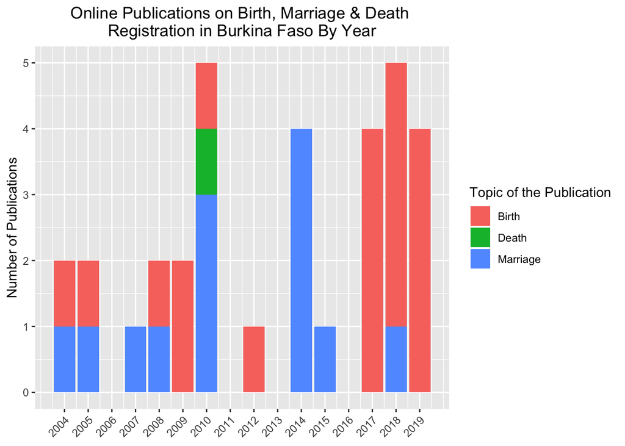

```r
Publications_by_Year <- unstructured_BMD %>%
group_by(Year, Vital_Event) %>%
count() %>%
ungroup()

Plot_Publications_Count <- Publications_by_Year %>%
ggplot(aes(Year, n, fill = Vital_Event)) +
geom_col() +
labs(title = paste("Online Publications on Birth, Marriage & Death
Registration in Burkina Faso By Year"),
     x = NULL,
     y = "Number of Publications",
  fill = "Topic of the Publication") +
  theme(plot.title = element_text(hjust = 0.5), axis.text.x = element_text(angle = 45, hjust = 1)) +
  scale_x_continuous(breaks= seq(2004, 2019))

Plot_Publications_Count
```

Les publications s’étendent de 2004 à 2019 et la majorité d’entre elles portent sur l’enregistrement des naissances, 2010 et 2018 ayant le plus grand nombre de publications. Il est à noter que la plupart des publications des premières années portent sur l’enregistrement des naissances, ce qui indique que la question est d’actualité depuis plus de 15 ans (car l’arrivée de internet au Burkina Faso est aussi récente). Il en va de même pour les mariages. Inversement, l’enregistrement des décès fait rarement l’objet de discussions et la seule publication que l’on trouve date de 2010.

## Data Contidionning : essayons d’ajouter une structure aux données

Nous devons imposer une structure aux données afin de les analyser. En utilisant le package *tidytext*, nous allons appliquer un processus appelé **“tokenization”** qui transforme un texte en une collection de mots simples (sac de mots).

```r
# Tokenizing the unstructured_BMD dataframe (1)

token_BMD <- unstructured_BMD %>%
rename(id = Num) %>%
unnest_tokens(word, Text)
```

```r
# Counting words before removal of stop words to find out the 30 most used words

token_BMD %>%
count(word) %>%
arrange(desc(n)) %>%
head(30) %>%
print(n = 30)
```

```
## # A tibble: 30 x 2
##    word          n
##    <chr>     <int>
##  1 de         1470
##  2 la          732
##  3 le          596
##  4 les         596
##  5 des         587
##  6 et          581
##  7 à           359
##  8 en          339
##  9 du          282
## 10 pour        249
## 11 un          241
## 12 dans        228
```

[output cut: 18 more lines]

```r
# Removing stop words, first method

tidy_BMD <- token_BMD %>%
filter(!word %in% stopwords("fr"))

# Counting remaining words to find out those that were used most frequently (1)

tidy_BMD %>%
count(word) %>%
arrange(desc(n)) %>%
head(30) %>%
print(n = 30)
```

```
## # A tibble: 30 x 2
##    word           n
##    <chr>      <int>
##  1 a            213
##  2 à            204
##  3 mariage      183
##  4 plus         154
##  5 civil        117
##  6 naissance    104
##  7 c’est         83
##  8 comme         81
##  9 femmes        81
## 10 naissances    66
## 11 jeunes        63
## 12 entre         55
```

[output cut: 18 more lines]

Ceci nous montre les mots les plus couramment utilisés dans les textes. Des mots comme “de”, “la”, “la”, “le” ont la fréquence la plus élevée mais ne nous donnent pas d’indications significatives sur les sujets des textes (on les appelle des “stop words” ou mots vides). Nous allons donc les supprimer à l’aide d’une collection de mots vides disponibles dans le package *“stopwords”*.

## 2.7. Fréquence des mots

### 2.7.1. Diagramme de fréquences des mots

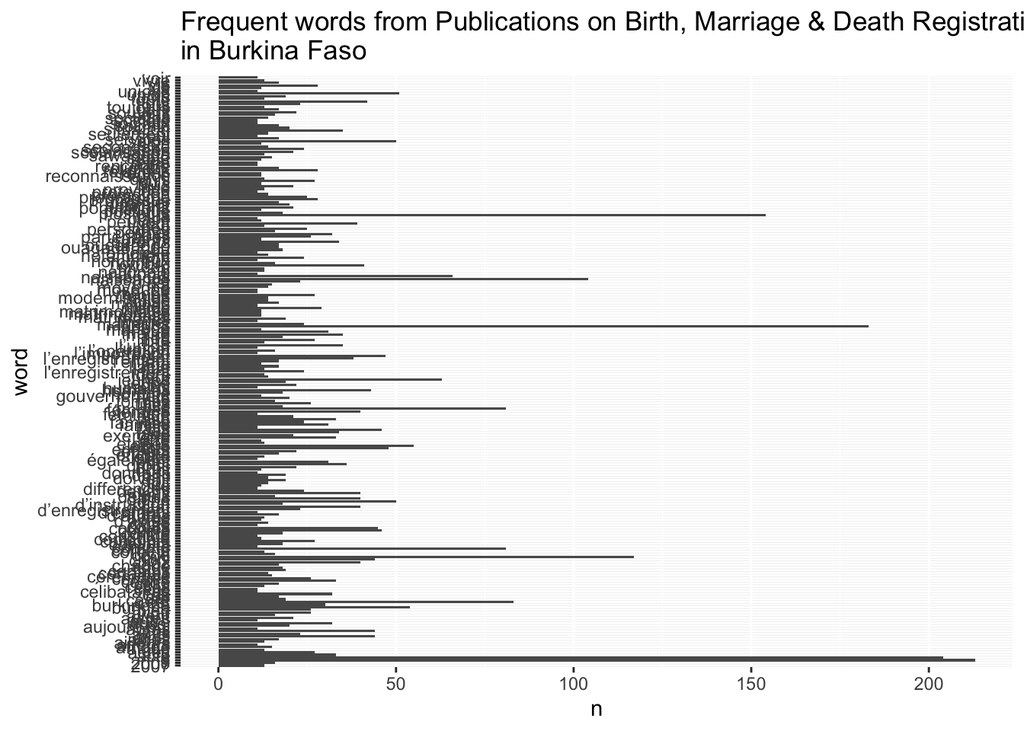

```r
# Creating new object for remaining words

BMD_word_counts <- tidy_BMD %>%
count(word) %>%
filter(n>10) %>%
arrange(desc(n))

# Plotting the remaining words (1)

ggplot(BMD_word_counts, aes(word, n)) +
geom_col() +
coord_flip() +
ggtitle("Frequent words from Publications on Birth, Marriage & Death Registration
in Burkina Faso")
```

Ce diagramme comporte de nombreux défauts. Nous utiliserons une autre approche pour supprimer les mots vides.

```r
# Removing stop words, second method
glimpse(stopwords('fr'))
```

```
##  chr [1:164] "au" "aux" "avec" "ce" "ces" "dans" "de" "des" "du" ...
```

```r
# Creating a dataframe of french stop words with tm
fr_stopwords <- tibble(word = stopwords('fr'))

# Tokenizing the unstructured_BMD dataframe (2)
token_BMD2 <- unstructured_BMD %>%
rename(id = Num) %>%
unnest_tokens(word, Text) %>%
anti_join(fr_stopwords)
# Counting remaining words to find out the 30 most used words (2)
token_BMD2 %>%
count(word) %>%
arrange(desc(n)) %>%
head(30) %>%
print(n = 30)
```

```
## # A tibble: 30 x 2
##    word           n
##    <chr>      <int>
##  1 a            213
##  2 à            204
##  3 mariage      183
##  4 plus         154
##  5 civil        117
##  6 naissance    104
##  7 c’est         83
##  8 comme         81
##  9 femmes        81
## 10 naissances    66
## 11 jeunes        63
## 12 entre         55
```

[output cut: 18 more lines]

J’ai eu le même résultat….

Il semble qu’il y ait encore quelques mots inutiles qui n’ont pas été supprimés par la collection standard de mots vides. Nous les enlèverons manuellement.

```r
# Creating a new dataframe of words I would like to remove manually

custom_french_stopwords <- tribble( ~word,
                                    "a", "à", "burkina", "aussi", "ainsi", "pays", "faso", "civil", "état", "acte", "actes", "plus", "naissance", "naissances", "être", "enfant", "tout", "mariage", "enfant", "enfants", "selon", "union", "fait", "comme", "burkinabè", "ouédraogo", "72", "1988", "000", "ouagadougou", "qu’il", "pogbi", "compaoré", "deux", "peut", "un", "ans", "où", "cas", "si", "est", "est", "chez", "une", "même","2007","sawadogo" )

# Joining the created stop words to the standard stop words

fr_stopwords2 <- fr_stopwords %>%
bind_rows(custom_french_stopwords)
glimpse(fr_stopwords2)
```

```
## Observations: 211
## Variables: 1
## $ word <chr> "au", "aux", "avec", "ce", "ces", "dans", "de", "des", "du"…
```

```r
# Tokenizing the unstructured_BMD dataframe (3)
token_BMD3 <- unstructured_BMD %>%
unnest_tokens(word, Text) %>%
anti_join(fr_stopwords2)
# stemmatizing to get the stem of each word
# mutate(word1 = wordStem(word, language = "fr"))
# stemmatization seems to have limited effects on french words

# Get rid of apostrophes and perform some manual stemmatization by creating a little function that handles most scenarios using gsub(), and then apply that function across all words
fix_apostrophe <- function(w) {
  # I am using "w" to mean "word"
  w <- gsub("l'enregistrement", "enregistrement", w)
  w <- gsub("l’enregistrement", "enregistrement", w)
  w <- gsub("d’enregistrement", "enregistrement", w)
  w <- gsub("l’enregistrement", "enregistrement", w)
  w <- gsub("l'importance", "importance", w)
  w <- gsub("l’importance", "importance", w)
  w <- gsub("l'hôpital", "hôpital", w)
  w <- gsub("l’hôpital", "hôpital", w)
  w <- gsub("l'unicef", "unicef", w)
  w <- gsub("d'actes", "actes", w)
  W <- gsub("d’actes", "actes", w)
  w <- gsub("l’acte", "acte", w)
  w <- gsub("l’union", "union", w)
  w <- gsub("c’est", "est", w)
  w <- gsub("l’état", "état", w)
  w <- gsub("l'état", "état", w)
  w <- gsub("d’état", "état", w)
  w <- gsub("d'état", "état", w)
  w <- gsub("d’un", "un", w)
  w <- gsub("l’eglise", "eglise", w)
  w <- gsub("l’opération", "opération", w)
  w <- gsub("l’enfant", "enfant", w)
  w <- gsub("l’unicef", "unicef", w)
  w <- gsub("d’autres", "autres", w)
  w <- gsub("hommes", "homme", w)
  w <- gsub("femmes", "femme", w)
  w <- gsub("couples", "couple", w)
  w <- gsub("filles", "femme", w)
  w <- gsub("d’instruction", "instruction", w)
  w <- gsub("l’âge" , "âge", w)
  w <- gsub("droits", "droit", w)
  w <- gsub("maternités", "maternié", w)
  w <- gsub("centres", "centre", w)
  w <- gsub("maire", "mairie", w)
  w <- gsub("familles", "famille", w)
  return(w)
}
# fix apostrophe issue
token_BMD3$word <- sapply(token_BMD3$word, fix_apostrophe )

# Removing stop words that appeard after we fixed the apostrophe issue
# token_BMD3 <- token_BMD3 %>%
# anti_join(fr_stopwords2)
```

```r
# Counting remaining words to find out the 30 most used words, second attempt
token_BMD3 %>%
count(word) %>%
arrange(desc(n)) %>%
head(30) %>%
print(n = 30)
```

```
## # A tibble: 30 x 2
##    word               n
##    <chr>          <int>
##  1 femme            147
##  2 état             110
##  3 couple            91
##  4 enregistrement    89
##  5 est               83
##  6 mairie            66
##  7 jeunes            63
##  8 homme             61
##  9 centre            59
## 10 droit             58
## 11 entre             55
## 12 famille           55
```

[output cut: 18 more lines]

```r
token_BMD3 %>%
filter(Vital_Event == "Marriage") %>%
count(word) %>%
filter(word == "lévirat")
```

| word | n |
| --- | --- |
| lévirat | 4 |

```r
# arrange(desc(n)) %>%
# head(200) %>%
# print(n = 200)
```

Cette liste a l’air d’être beaucoup mieux. Etonnamment, nous avons maintenant **“femme”** comme mot le plus utilisé - encore plus que **“enregistrement” et “état civil”. Ceci attire déjà notre attention sur le rôle central que jouent les femmes dans l’enregistrement des faits d’état civil au Burkina Faso.

De plus, un mot qui n’apparaît que quatre fois mais qui fait référence à une pratique culturelle liée au mariage est “lévirat”. “lévirat” désigne l’obligation du frère réel ou classificateur d’un défunt d’épouser sa ou ses veuves. C’est une pratique très répandue en Afrique de l’Ouest, bien qu’elle soit assortie de diverses conditions de mise en œuvre : elle peut être imposée, prescrite, recommandée ou laissée au choix de la veuve [(Attané, 2014)](https://www.jstor.org/stable/j.ctt1f117sb).

```r
# Creating new object for remaining words

BMD_word_counts <- token_BMD3 %>%
count(word, Vital_Event) %>% # Adding vital events to the counting
group_by(Vital_Event) %>%
top_n(25, n)

BMD_word_counts %>%
head(20) %>%
print(n = 20)
```

```
## # A tibble: 20 x 3
## # Groups:   Vital_Event [3]
##    word           Vital_Event     n
##    <chr>          <chr>       <int>
##  1 affirmé        Death           2
##  2 autres         Birth          16
##  3 autres         Death           2
##  4 centre         Birth          51
##  5 centre         Death           8
##  6 choix          Marriage       44
##  7 conjoints      Marriage       27
##  8 couple         Marriage       91
##  9 déclarations   Death           2
## 10 devant         Marriage       23
## 11 direction      Death           3
## 12 droit          Birth          41
## 13 effet          Birth          11
## 14 enfant         Birth          16
## 15 enregistrement Birth          89
## 16 entre          Birth          17
## 17 entre          Death           2
## 18 entre          Marriage       36
## 19 est            Birth          28
## 20 est            Marriage       55
```

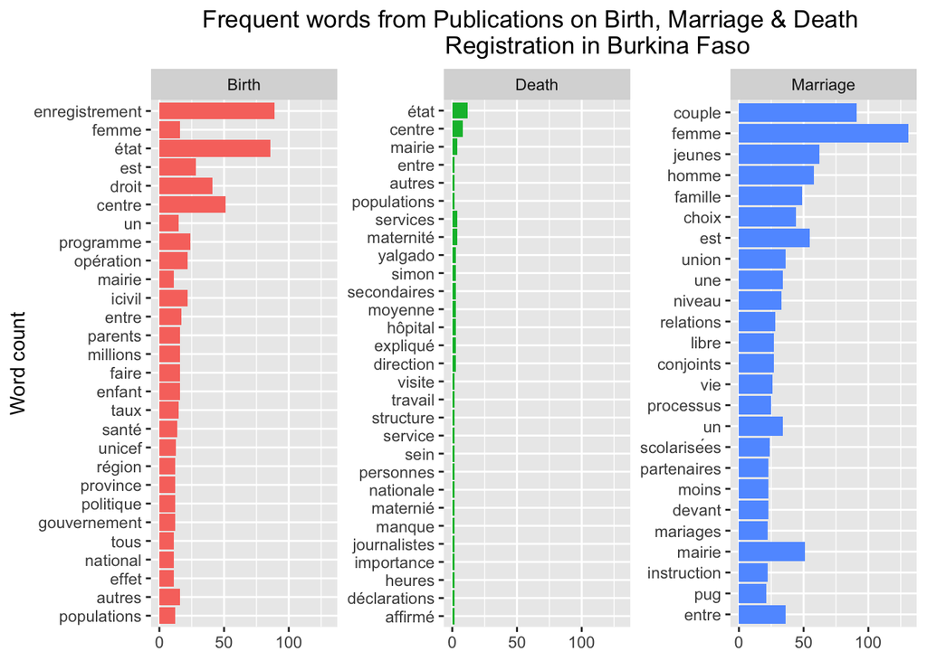

```r
# Plotting the remaining words

ggplot(BMD_word_counts, aes(reorder(word, n), n, fill = Vital_Event )) +
geom_col(show.legend = FALSE) +
facet_wrap(~ Vital_Event, scales = "free_y") + # The y axis can be different for each plot
coord_flip() +
theme(plot.title = element_text(hjust = 0.5)) +
labs(title = paste("Frequent words from Publications on Birth, Marriage & Death
                   Registration in Burkina Faso"),
     x = "Word count",
     y = NULL)
```

### 2.7.2. Interprétation: Enregistrement des naissances

Sur la base de ce graphe, nous pouvons déjà constater que le mot **“enregistrement”** est fortement ressorti des publications sur les naissances. Ceci est normal d’autant plus que les publications collectées portent sur l’enregistrement des naissances. Cependant, cela nous indique aussi potentiellement, que l’enregistrement des naissances au Burkina Faso est souvent considéré comme un simple acte d’“enregistrement” et pas nécessairement comme un “acte social”. Il y a aussi des mots comme “droit”, “Gouvernement”, qui révèlent la forte implication du gouvernement dans la prise en compte de toutes les naissances au Burkina Faso. La présence de **“icivil”**, qui est une nouvelle technologie d’enregistrement des naissances par téléphone mobile, indique une forte tendance à moderniser le système, nonobstant les facteurs limitants tels que l’accessibilité et la disponibilité de la technologie comme peut l’indiquer l’utilisation de **“province”** ou **“région”** qui sont aussi des mots qui sont apparus.

### 2.7.3. Interprétation : Enregistrement des décès

Il est difficile de comprendre le graphique sur l’enregistrement des décès parce qu’il n’y a eu qu’une seule publication sur ce sujet. Néanmoins, cela ammène à penser que peu de choses sont faites pour enregistrer les décès et qu’il serait important que notre étude fasse la lumière sur les raisons de cette situation.

### 2.7.4. Interprétation: Enregistrement des marriages

Pour les publications sur le mariage, le mot “femme” apparaît plus fréquemment et reflète le rôle central que les femmes jouent sur la question. On remarque également l’utilisation fréquente des mots ‘’scolarisées’’ et “instruction”. Ici, la présence de *‘’es’’* à la fin du mot indique qu’il est utilisé comme un verbe pour un pronom féminin, donc il fait référence à l’éducation des femmes. Nous pouvons en déduire que l’éducation des femmes est liée à leur mariage et, ultimement, à l’enregistrement des mariages.

Un mot qui est apparu avec une fréquence relativement élevée et qui nous a semblé a priori dénué de sens est **“pug”**. Après avoir passé en revue quelques textes sur le mariage, nous nous sommes rendu compte que **“pug”** est la racine de plusieurs mots en langue locale Mooré tels que **“pug-siure” (cérémonie de fiançailles)**, **“pug-pusum” (demande en mariage à la famille de la femme)**. **Pug"** signifie **“femme”** dans le dialecte local et renforce donc l’argument selon lequel les femmes sont au centre des débats sur l’enregistrement des mariages.

De plus, nous voyons des mots tels que **“choix”**, **“union”, “libre”, “fuite”** qui sont utilisés pour parler des types de mariage et aussi de la possibilité d’avoir un divorce. Il est donc possible que l’enregistrement des mariages dépende du type d’union et de la crainte du divorce.

# 3. Modélisation

La modélisation thématique (Topic Modeling) nous permet d’aller au-delà du simple décompte des mots et de découvrir les sujets sous-jacents dans notre collection de documents (dans ce cas, nos publications transformées en sacs de mots). Nous utiliserons un modèle connu sous le nom de Lattent Dirichlet Allocation (LDA). Le modèle LDA est un type d’approche d’apprentissage automatique non supervisé qui recherche des mots qui apparaissent ensemble de façon constante dans une collection de documents. Avant d’exécuter notre modèle LDA, nous devons transformer la collection de mots (token_BMD3) en une collection de documents appelée Document Term Matrix (DTM). Un DTM est une matrice qui comporte une ligne pour chaque document (publication) et une colonne pour chaque mot (ou terme) unique. Les valeurs dans le DTM sont les décomptes de l’utilisation de chaque terme pour un document donné.

## 3.1. Modélisation thématique: enregistrement des naissances

```r
dtm_publications_birth <- token_BMD3 %>%
rename(id = Num) %>% # to rename the num column
filter(Vital_Event == "Birth") %>%
count(word, id) %>%
cast_dtm(id, word, n)
dtm_publications_birth
```

```
## <<DocumentTermMatrix (documents: 19, terms: 2020)>>
## Non-/sparse entries: 3591/34789
## Sparsity           : 91%
## Maximal term length: 19
## Weighting          : term frequency (tf)
```

```r
matrix_dtm_publications_birth <- as.matrix(dtm_publications_birth)
matrix_dtm_publications_birth[1:5, 100:105]
```

```
##     Terms
## Docs acte actes acteurs action actions activité
##   8     0     0       1      0       0        0
##   24    0     0       1      0       1        0
##   27    0     0       0      0       0        0
##   7     1     0       0      0       0        0
##   26    0     0       0      0       0        0
```

```r
lda_publications_birth <- LDA(dtm_publications_birth,
                        k = 2,
                        method = "Gibbs",
                        control = list(seed = 42))
glimpse(lda_publications_birth)
```

```
## Formal class 'LDA_Gibbs' [package "topicmodels"] with 16 slots
##   ..@ seedwords      : NULL
##   ..@ z              : int [1:4598] 2 2 2 2 2 2 2 2 2 2 ...
##   ..@ alpha          : num 25
##   ..@ call           : language LDA(x = dtm_publications_birth, k = 2, method = "Gibbs", control = list(seed = 42))
##   ..@ Dim            : int [1:2] 19 2020
##   ..@ control        :Formal class 'LDA_Gibbscontrol' [package "topicmodels"] with 14 slots
##   ..@ k              : int 2
##   ..@ terms          : chr [1:2020] "0" "09" "1" "1,2" ...
##   ..@ documents      : chr [1:19] "8" "24" "27" "7" ...
##   ..@ beta           : num [1:2, 1:2020] -10.11 -7.1 -7.71 -10.14 -7.06 ...
##   ..@ gamma          : num [1:19, 1:2] 0.299 0.234 0.849 0.576 0.796 ...
##   ..@ wordassignments:List of 5
##   .. ..$ i   : int [1:3591] 1 1 1 1 1 1 1 1 1 1 ...
##   .. ..$ j   : int [1:3591] 1 17 29 30 31 46 64 65 76 102 ...
##   .. ..$ v   : num [1:3591] 2 2 2 2 2 2 2 2 1 2 ...
##   .. ..$ nrow: int 19
##   .. ..$ ncol: int 2020
##   .. ..- attr(*, "class")= chr "simple_triplet_matrix"
##   ..@ loglikelihood  : num -34667
##   ..@ iter           : int 2000
##   ..@ logLiks        : num(0)
##   ..@ n              : int 4598
```

```r
lda_publications_birth_topics <- lda_publications_birth %>%
tidy(matrix = "beta" )

lda_publications_birth_topics %>%
arrange(desc(beta))
```

| topic | term | beta |
| --- | --- | --- |
| 1 | état | 2.162052e-02 |
| 1 | centre | 1.999186e-02 |
| 1 | enregistrement | 1.795603e-02 |
| 2 | enregistrement | 1.771406e-02 |
| 2 | état | 1.300079e-02 |
| 2 | est | 1.103692e-02 |
| 2 | programme | 9.465829e-03 |
| 1 | icivil | 8.998371e-03 |
| 2 | droit | 8.680283e-03 |
| 2 | opération | 8.680283e-03 |

[output cut: 4030 more lines]

Nous avons défini k = 2 parce que nous voulons que le modèle regroupe les mots en deux sujet. Le résultat nous montre “beta” qui est la probabilité que des mots apparaissent dans un sujet donné.

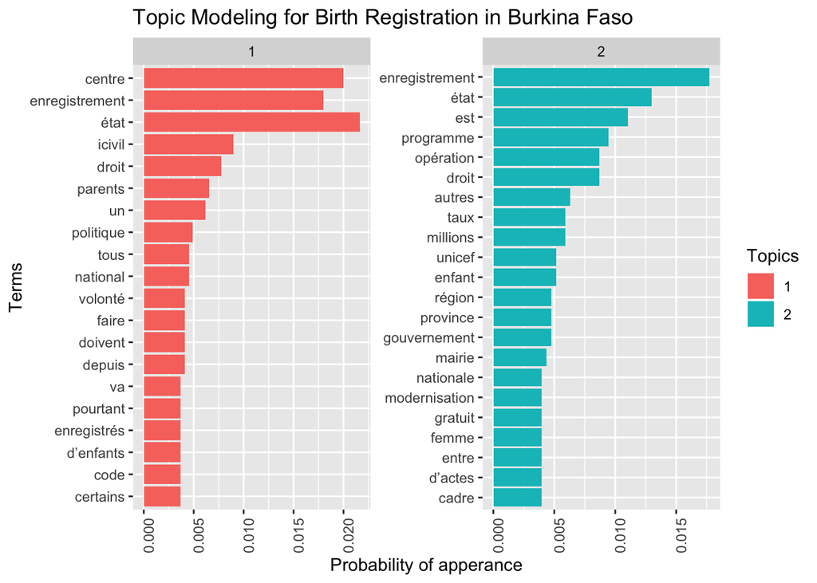

```r
# Creating an object for words' probabilities of appearance

word_prob_birth <- lda_publications_birth_topics %>%
group_by(topic) %>%
top_n(20, beta) %>%
ungroup() %>%
mutate(term2 = fct_reorder(term, beta))

# Ploting words' propabilities

ggplot(word_prob_birth, aes(term2, beta,
                      fill = as.factor(topic))) +
  geom_col() +
  facet_wrap(~ topic, scales = "free") +
  coord_flip() +
  theme(axis.text.x = element_text(angle = 90, hjust = 1)) +
labs(title = paste("Topic Modeling for Birth Registration in Burkina Faso"),
     x = "Terms",
     y = "Probability of apperance",
  fill = "Topics")
```

Le premier sujet comporte des mots tels que **“enregistrement”, “icivil”, “politique”, “national”, “etat”** apparaissant avec une probabilité élevée et suggère donc que le sujet est lié à l’introduction de icivil comme système national d’enregistrement des naissances au Burkina Faso.

Le deuxième sujet est un ensemble de mots qui semblent être liés à la modernisation de l’enregistrement des naissances et aux défis qui y sont associés. Avec des mots comme **“enregistrement”, “modernisation”, “province”, “région”**, on peut déduire la nécessité d’aller dans des régions éloignées et donc le facteur distance dans l’enregistrement des naissances. Toujours à propos de la modernisation, nous voyons des mots comme **“programme”, “opération”, “millions”** apparaître ensemble avec une probabilité élevée indiquant qu’il existe plusieurs programmes ad hoc d’enregistrement des naissances et suggérant l’absence probable d’un système durable efficace.

## 3.2. Modélisation thématique: enregistrement des mariages

```r
dtm_publications_marriage <- token_BMD3 %>%
rename(id = Num) %>% # to rename the num column
filter(Vital_Event == "Marriage") %>%
count(word, id) %>%
cast_dtm(id, word, n)
dtm_publications_marriage
```

```
## <<DocumentTermMatrix (documents: 13, terms: 3281)>>
## Non-/sparse entries: 4738/37915
## Sparsity           : 89%
## Maximal term length: 23
## Weighting          : term frequency (tf)
```

```r
matrix_dtm_publications_marriage <- as.matrix(dtm_publications_marriage)
matrix_dtm_publications_marriage[1:5, 100:105]
```

```
##     Terms
## Docs 41 42 49 5 5,2 5,8
##   29  0  0  0 0   0   0
##   31  0  0  0 0   1   1
##   16  0  0  0 0   0   0
##   20  0  1  0 0   0   0
##   22  0  0  0 0   0   0
```

```r
lda_publications_marriage <- LDA(dtm_publications_marriage,
                        k = 2,
                        method = "Gibbs",
                        control = list(seed = 42))
glimpse(lda_publications_marriage)
```

```
## Formal class 'LDA_Gibbs' [package "topicmodels"] with 16 slots
##   ..@ seedwords      : NULL
##   ..@ z              : int [1:8005] 2 2 2 2 2 2 1 2 2 2 ...
##   ..@ alpha          : num 25
##   ..@ call           : language LDA(x = dtm_publications_marriage, k = 2, method = "Gibbs", control = list(seed = 42))
##   ..@ Dim            : int [1:2] 13 3281
##   ..@ control        :Formal class 'LDA_Gibbscontrol' [package "topicmodels"] with 14 slots
##   ..@ k              : int 2
##   ..@ terms          : chr [1:3281] "0,4" "0,6" "1" "1,2" ...
##   ..@ documents      : chr [1:13] "29" "31" "16" "20" ...
##   ..@ beta           : num [1:2, 1:3281] -10.45 -7.82 -10.45 -8.46 -10.45 ...
##   ..@ gamma          : num [1:13, 1:2] 0.2224 0.0396 0.8145 0.8017 0.8051 ...
##   ..@ wordassignments:List of 5
##   .. ..$ i   : int [1:4738] 1 1 1 1 1 1 1 1 1 1 ...
##   .. ..$ j   : int [1:4738] 1 2 5 17 25 34 38 42 47 48 ...
##   .. ..$ v   : num [1:4738] 2 2 2 2 2 1 2 2 2 1 ...
##   .. ..$ nrow: int 13
##   .. ..$ ncol: int 3281
##   .. ..- attr(*, "class")= chr "simple_triplet_matrix"
##   ..@ loglikelihood  : num -62640
##   ..@ iter           : int 2000
##   ..@ logLiks        : num(0)
##   ..@ n              : int 8005
```

```r
lda_publications_topics_marriage <- lda_publications_marriage %>%
tidy(matrix = "beta" )

lda_publications_topics_marriage %>%
arrange(desc(beta))
```

| topic | term | beta |
| --- | --- | --- |
| 2 | femme | 2.515784e-02 |
| 1 | est | 1.539086e-02 |
| 1 | mairie | 1.481116e-02 |
| 1 | couple | 1.452132e-02 |
| 2 | jeunes | 1.191687e-02 |
| 2 | homme | 1.114928e-02 |
| 2 | choix | 8.462705e-03 |
| 2 | couple | 7.887010e-03 |
| 2 | famille | 7.503214e-03 |
| 1 | union | 7.275151e-03 |

[output cut: 6552 more lines]

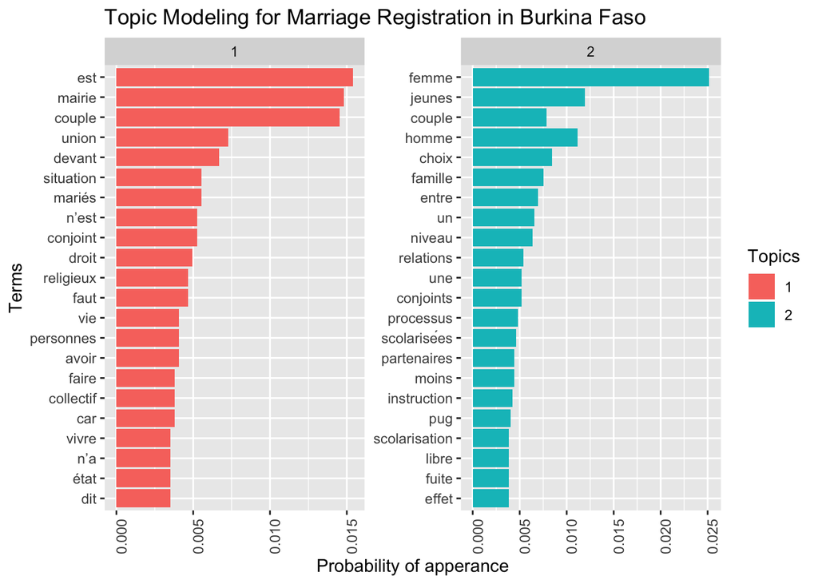

```r
# Creating an object for words' probabilities of appearance

word_prob_marriage <- lda_publications_topics_marriage %>%
group_by(topic) %>%
top_n(20, beta) %>%
ungroup() %>%
mutate(term2 = fct_reorder(term, beta))

# Ploting words' propabilities

ggplot(word_prob_marriage, aes(term2, beta, fill = as.factor(topic))) +
  geom_col() +
  facet_wrap(~ topic, scales = "free") +
  coord_flip() +
  theme(axis.text.x = element_text(angle = 90, hjust = 1)) +
labs(title = paste("Topic Modeling for Marriage Registration in Burkina Faso"),
     x = "Terms",
     y = "Probability of apperance",
  fill = "Topics")
```

Le premier sujet qui comporte un ensemble de mots apparaissant ensemble avec une forte probabilité comme **“mairie”**, **“couple”**, **“mariés”** concerne éventuellement la célébration du mariage civil et donc son enregistrement. La présence marquée du mot **“collectif”** est certainement une allusion à la célébration des **mariages civils collectifs** qui s’avère être un phénomène assez intéressant au Burkina Faso. En effet, ce sont des cérémonies de mariage civil organisées pour plusieurs personnes à la fois, par le même officier d’état civil, le même jour. Cette méthode apparaît ici comme un moyen d’encourager l’enregistrement des mariages. Ainsi, une question qui vient à l’esprit est celle de savoir si le fait de voir un ami ou un parent célébrer un mariage civil peut être un facteur déterminant dans l’enregistrement du mariage d’une personne donnée au Burkina Faso.

Le deuxième sujet concerne probablement les facteurs sociaux qui influent sur le mariage. Nous voyons des mots comme :

- **“jeune”**, donc l’âge en tant que facteur,
- **niveau“,”scolarisées“,”scolarisation",** “instruction”**, donc l’éducation comme autre facteur,
- **“famille”**, donc l’environnement en tant que facteur
- **“pug”**, qui est un mot en dialecte local qui signifie **“femme”** mais fait référence principalement aux systèmes de mariage traditionnels (la tradition est ici un facteur),
- **“choix”, “libre”**, comme types d’union et **" processus "** se référant à la durée d’une union,
- **fuite** qui fait référence à la séparation et donc à la probabilité de divorce comme facteur.

L’interprétation d’un modèle thématique est assez subjective mais permet déjà, avec une certaine maîtrise du sujet, de faire certaines prédictions sur les mots qui peuvent indiquer un déterminant de l’enregistrement d’un fait d’état civil comme le mariage.

L’absence d’un grand nombre de publications sur les normes sociales ne nous permet pas de tirer des concluions et de faire des prdictions. Par exemple, malgré que nous avons obtenu plusieurs textes portant sur l’enregistrement des naissances, très peu portent sur les barrières ou normes socio-culturelles pouvant entraver leur enregistrement. Par contre, sur le mariage, on est parvenue a des conclusions plus interessantes, avec moins de textes mais orienter vers les determinants sociaux qui nous intéressent. Les résultats que nous avons ici, combinés aux données qui seront recueillies au cours des études sur le terrain, peuvent confirmer ou réfuter certaines de nos hypothèses. L’idéale serait de pouvoir refaire cette analyse avec les transcriptions provenant des interviews et focus group et de consolider nos interprétations en se basant sur les informations recueillies du terrain.